# Final Project Written Report

Author

Rodrick Mpofu

Published

May 3, 2024

# Abstract

This project presents a comprehensive analysis of data from the Ultimate Fighting Championship (UFC), the mixed martial arts organization. Utilizing a dataset sourced from Kaggle, this study examines an array of variables including fighter attributes, fight outcomes, and statistical trends over time. The aim is to uncover underlying patterns in fight results, fighter characteristics, and performance metrics across different weight classes and fighting styles. Through data manipulation and data visualizations, this report highlights trends in fight outcomes, the popularity of different fighting stances, and the geographic distribution of fights. Additionally, the analysis enables a direct comparison between fighters, providing insights into their relative strengths and weaknesses. By exploring into these aspects, the project seeks to enhance understanding of factors that influence success in the UFC.

## Link to My GitHub Repository for the Project and Blog Post

- [GitHub Repository](https://github.com/rodrick-mpofu/ds334_final_project)
- [Blog Post](https://rodrick-mpofu.github.io/ds334blog/)

# Introduction

## Data Overview

The data contains the following columns:

- `R_` and `B_` prefix signifies red and blue corner fighter stats respectively
- `_opp_` containing columns is the average of damage done by the opponent on the fighter
- `KD` is number of knockdowns
- `SIG_STR` is no. of significant strikes ‘landed of attempted’
- `SIG_STR_pct` is significant strikes percentage
- `TOTAL_STR` is total strikes ‘landed of attempted’
- `TD` is no. of takedowns
- `TD_pct` is takedown percentages
- `SUB_ATT` is no. of submission attempts
- `PASS` is no. times the guard was passed?
- `REV` is the no. of Reversals landed
- `HEAD` is no. of significant strinks to the head ‘landed of attempted’
- `BODY` is no. of significant strikes to the body ‘landed of attempted’
- `CLINCH` is no. of significant strikes in the clinch ‘landed of attempted’
- `GROUND` is no. of significant strikes on the ground ‘landed of attempted’
- `win_by` is method of win
- `last_round` is last round of the fight (ex. if it was a KO in 1st, then this will be 1)
- `last_round_time` is when the fight ended in the last round
- `Format` is the format of the fight (3 rounds, 5 rounds etc.)
- `Referee` is the name of the Ref
- `date` is the date of the fight
- `location` is the location in which the event took place
- `Fight_type` is which weight class and whether it’s a title bout or not
- `Winner` is the winner of the fight
- `Stance` is the stance of the fighter (orthodox, southpaw, etc.)
- `Height_cms` is the height in centimeter
- `Reach_cms` is the reach of the fighter (arm span) in centimeter
- `Weight_lbs` is the weight of the fighter in pounds (lbs)
- `age` is the age of the fighter
- `title_bout` Boolean value of whether it is title fight or not
- `weight_class` is which weight class the fight is in (Bantamweight, heavyweight, Women’s flyweight, etc.)
- `no_of_rounds` is the number of rounds the fight was scheduled for
- `current_lose_streak` is the count of current concurrent losses of the fighter
- `current_win_streak` is the count of current concurrent wins of the fighter
- `draw` is the number of draws in the fighter’s ufc career
- `wins` is the number of wins in the fighter’s ufc career
- `losses` is the number of losses in the fighter’s ufc career
- `total_rounds_fought` is the average of total rounds fought by the fighter
- `total_time_fought(seconds)` is the count of total time spent fighting in seconds
- `total_title_bouts` is the total number of title bouts taken part in by the fighter
- `win_by_Decision_Majority` is the number of wins by majority judges decision in the fighter’s ufc career
- `win_by_Decision_Split` is the number of wins by split judges decision in the fighter’s ufc career
- `win_by_Decision_Unanimous` is the number of wins by unanimous judges decision in the fighter’s ufc career
- `win_by_KO/TKO` is the number of wins by knockout in the fighter’s ufc career
- `win_by_Submission` is the number of wins by submission in the fighter’s ufc career
- `win_by_TKO_Doctor_Stoppage` is the number of wins by doctor stoppage in the fighter’s ufc career

## Questions to Answer

1. What are the trends of different fighter statistics over time?
2. What are the most common ways fighters win?
3. Where are UFC fights most common in the world or in the US?
4. Can users to compare two fighters and see their statistics side by side to see who the better fighter is?

# Data Analysis and Visualization

## Distribution of Weight Classes

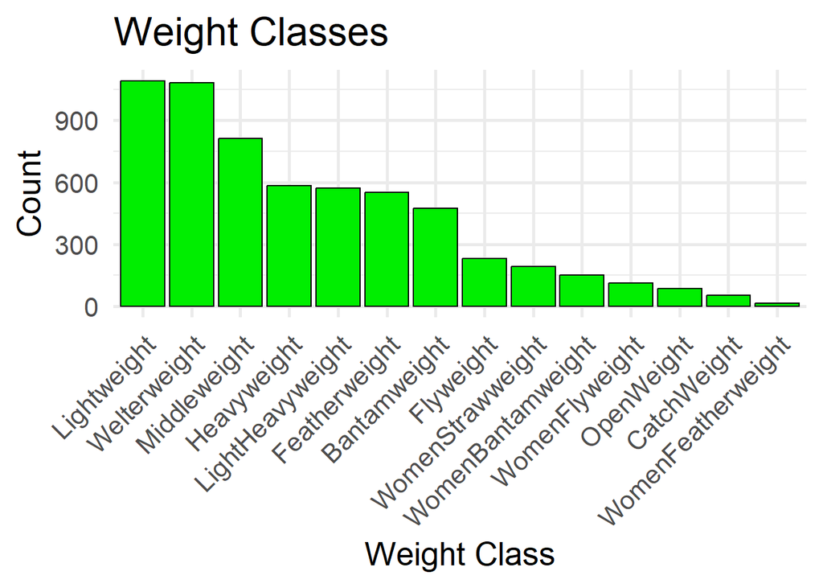

```r
# Weight classes

data_df |>
  group_by(weight_class) |>
  summarise(Count = n()) |>
  arrange(desc(Count)) |>
  mutate(weight_class = factor(weight_class,
                               levels = unique(weight_class)))|>
  ggplot(aes(x = weight_class, y = Count)) +
  geom_bar(stat = "identity", fill = "green2", color = "black") +
  theme_minimal(base_size = 20) +
  theme(axis.text.x = element_text(angle = 45, hjust = 1)) +
  labs(title = "Weight Classes", x = "Weight Class", y = "Count")
```

The graph above shows the weight classes in the UFC. The most common weight class is Lightweight, followed by Welterweight and Middleweight. The least common weight classes are the open weight and catch weight classes and women’s featherweight.

## Distribution of Fighting Stance

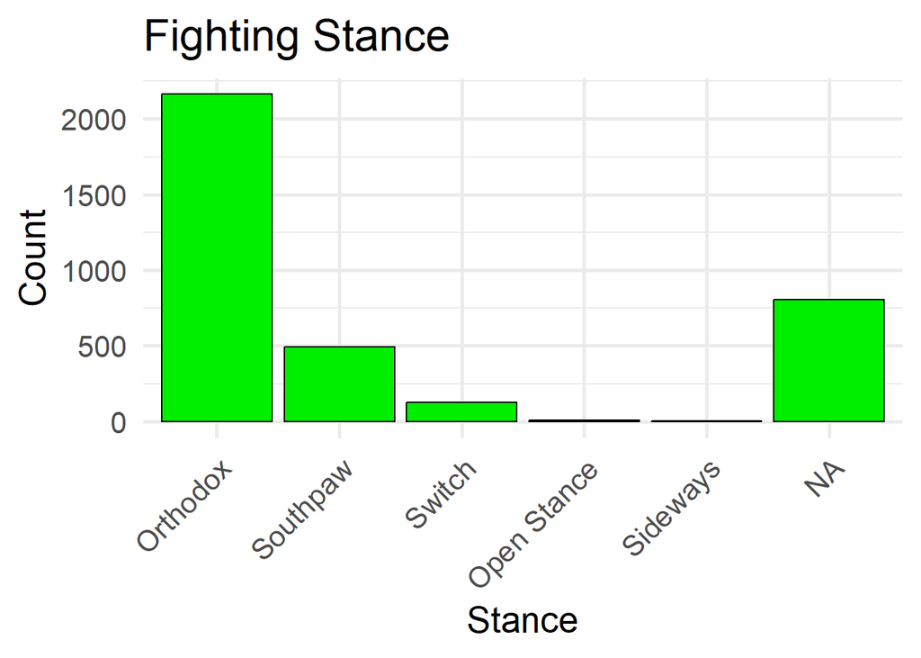

```r
# Fighting stance


raw_fighter_df |>
  group_by(Stance) |>
  summarise(Count = n()) |>
  arrange(desc(Count)) |>
  mutate(Stance = factor(Stance,
                         levels = unique(Stance)))|>
  ggplot(aes(x = Stance, y= Count)) +
  geom_bar(stat = "identity", fill = "green2", color = "black") +
  theme_minimal(base_size = 20) +
  theme(axis.text.x = element_text(angle = 45, hjust = 1)) +
  labs(title = "Fighting Stance", x = "Stance", y = "Count")
```

The graph above shows the fighting stances of UFC fighters. The most common stance is orthodox, followed by southpaw and switch. The least common stance is the sideways stance.

## Distribution of Wins by Decision

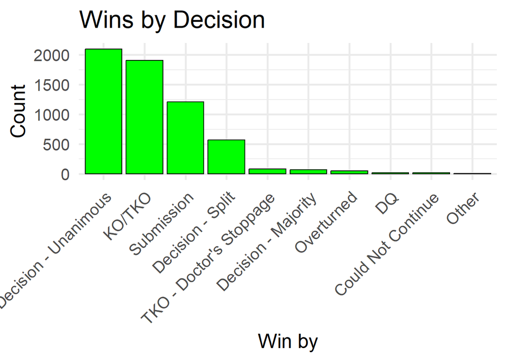

```r
# Wins by decision

raw_total_fight_df |>
  group_by(win_by) |>
  summarise(Count = n()) |>
  arrange(desc(Count)) |>
  mutate(win_by = factor(win_by,
                         levels = unique(win_by)))|>
  ggplot(aes(x = win_by, y= Count)) +
  geom_bar(stat = "identity",fill = "green", color = "black") +
  theme_minimal(base_size = 20) +
  theme(axis.text.x = element_text(angle = 45, hjust = 1)) +
  labs(title = "Wins by Decision", x = "Win by", y = "Count")
```

## Wins by Decision Over the Years

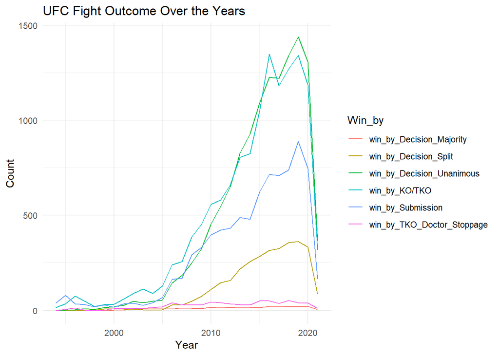

```r
# Line graph instead of bar graph

data_df |>
  pivot_longer(cols = c(R_win_by_Decision_Majority,
                        R_win_by_Decision_Split,
                        R_win_by_Decision_Unanimous,
                        `R_win_by_KO/TKO`,
                        R_win_by_Submission,
                        R_win_by_TKO_Doctor_Stoppage,
                        B_win_by_Decision_Majority,
                        B_win_by_Decision_Split,
                        B_win_by_Decision_Unanimous,
                        `B_win_by_KO/TKO`,
                        B_win_by_Submission,
                        B_win_by_TKO_Doctor_Stoppage),
               names_to = "Win_by", values_to = "Count") |>
  mutate(Win_by = str_replace_all(Win_by, c("R_" = "", "B_" = ""))) |>
  mutate(Win_by = as.factor(Win_by), year = year(date)) |>
  group_by(year, Win_by) |>
  summarise(Count = sum(Count), year) |>
  filter(row_number()==1) |>
  ggplot(aes(x=year, y = Count, color = Win_by)) +
  geom_line() +
  labs(title = "UFC Fight Outcome Over the Years", x = "Year", y = "Count") +
  theme_minimal()
```

The line graph above shows the UFC fight outcomes over the years. The most common way fighters win is by unanimous decision, followed by KO/TKO and submission. The least common way fighters win is by doctor stoppage and majority decision. Around 2016 the number of wins by KO/TKO increased and became the most common way fighters win.

## Fighter Stance Popularity Over the Years

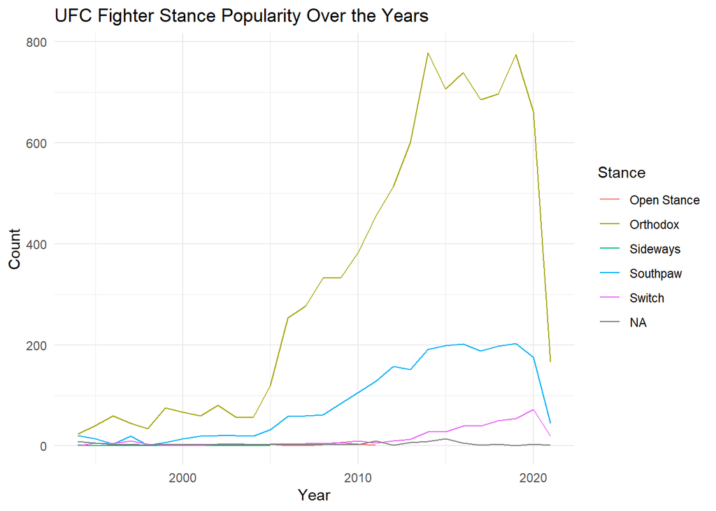

```r
data_df |>
  pivot_longer(cols = c(R_Stance, B_Stance),
               names_to = "Fighter_B_Or_R",
               values_to = "Stance") |>
  mutate(Stance = as.factor(Stance), year = year(date)) |>
  group_by(year, Stance) |>
  summarise(Count = n(), year) |>
  filter(row_number()==1) |>
  ggplot(aes(x=year, y = Count, color = Stance)) +
  geom_line() +
  labs(title = "UFC Fighter Stance Popularity Over the Years", x = "Year", y = "Count") +
  theme_minimal()
```

The line graph above shows the popularity of different fighting stances over the years. The most common stance is orthodox, followed by southpaw and switch. The least common stance is the sideways stance. The popularity of the orthodox stance has increased over the years more than the other stances.

## Mapping UFC Fights

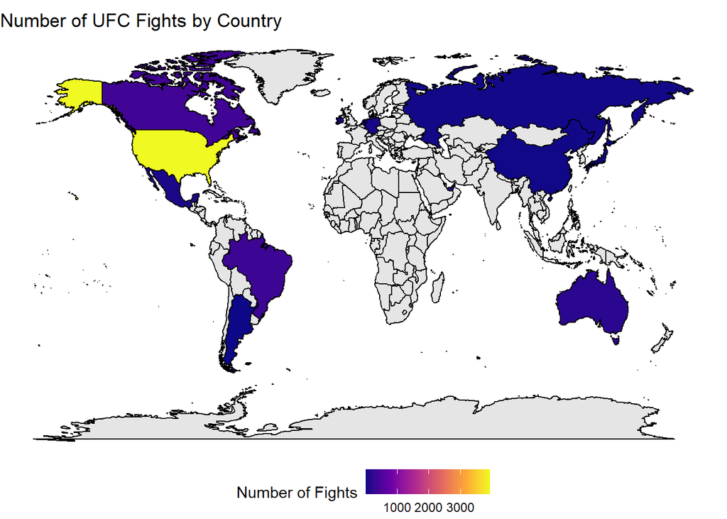

The map above shows the number of UFC fights that have taken place in each country. The United States has the highest number of fights, followed by Canada then Brazil. And the countries with the least number of fights that have taken place are the China, Japan and Argentina.

## Number of UFC Fights by State

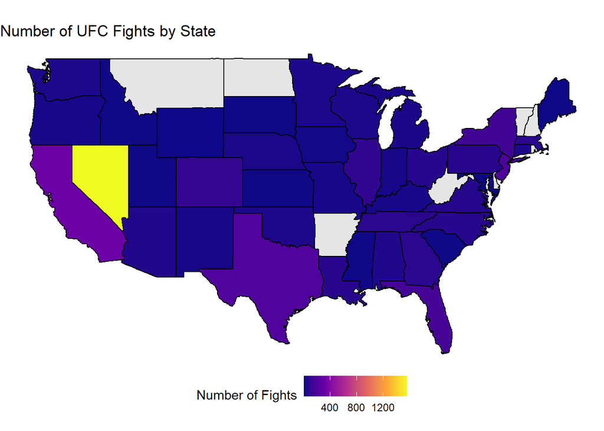

The map above shows the number of UFC fights that have taken place in each state. The states with the highest number of fights are Nevada, California, and Texas. The states with the least number of fights are Maine, Maryland and Wyoming.

## Number of UFC Fights by City

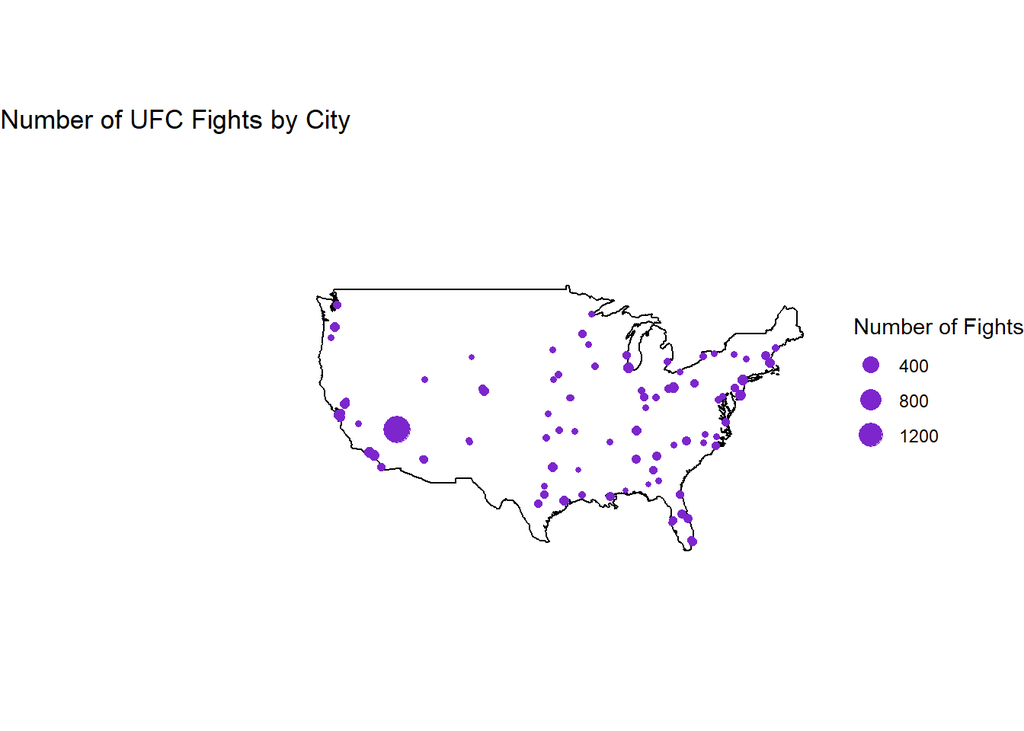

The map above shows the number of UFC fights that have taken place in each city in the United States. The cities with the highest number of fights are Las Vegas, Newark, and Chicago.

# Static Shiny App graphs

## Stats trend per Fighter

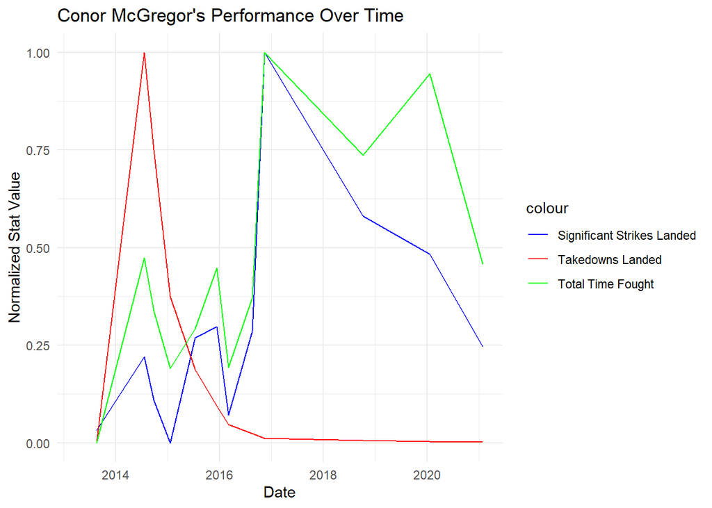

## Compare fighters Jon Jones vs Francis Ngannou

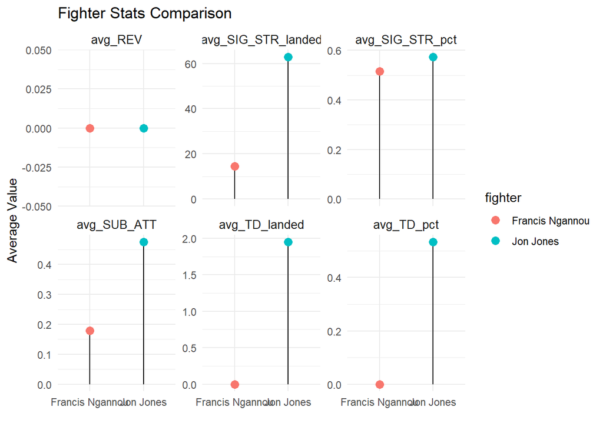

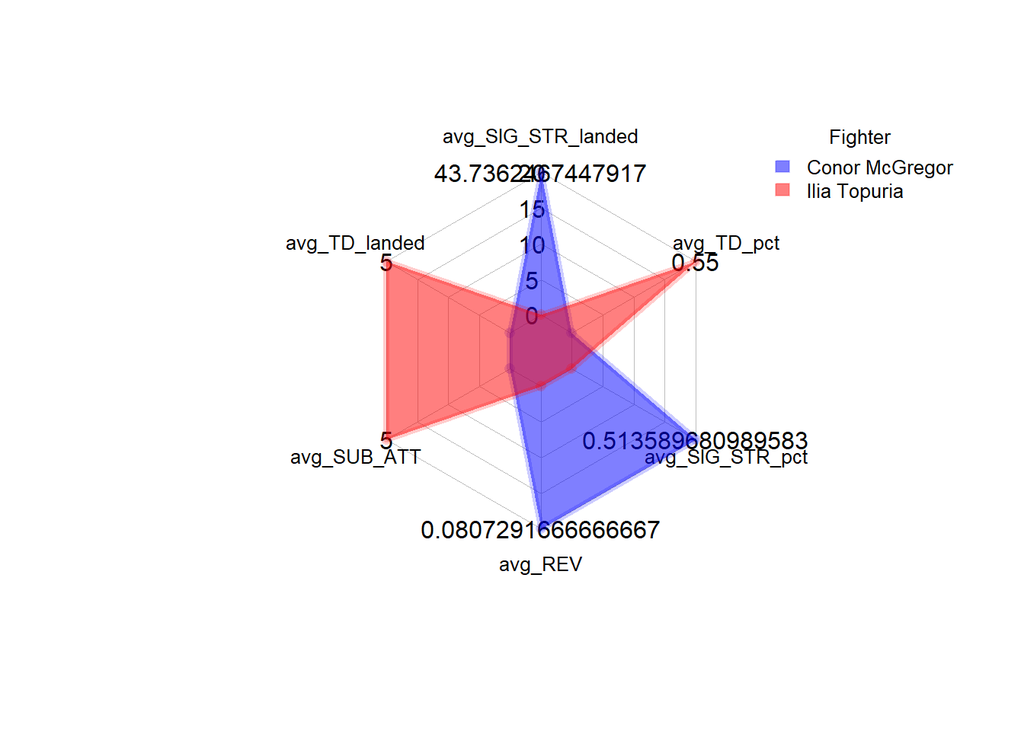

Spider or radar charts are useful for comparing multiple quantitative variables for different entities. In this case, we used a radar chart to compare the average fight statistics of two UFC fighters, Ilia Topuria and Conor McGregor. However, radar charts can sometimes be misleading due to the way they represent data. It’s important to be cautious when interpreting radar charts and consider the limitations of this type of visualization. The circular pattern of the radar chart can make it difficult to accurately compare values across different variables, and the use of different scales for each variable can also affect the interpretation of the data. Additipnally, the way the categories are arranged around the circle can also impact how the data is perceived. Despite these limitations, radar charts can be a useful tool for visualizing and comparing multivariate data in certain contexts.

This visualization provides a quick overview of how the two fighters compare in terms of these key statistics. It can help fans and analysts understand the strengths and weaknesses of each fighter and predict how they might perform in an upcoming fight.

# Conclusion

This project not only enriches our comprehension of the sport but also serves as a foundational analysis for predictive modeling and strategic decision-making in training and fight preparations. Future research could expand upon this work by integrating more granular data such as injury reports, detailed biometrics, and psychological assessments to further refine the predictions and insights into fighter performance and fight outcomes.